# Spooky Poetry Text Analysis

Sophie Beiers

2/5/2018

## Introduction

The goal of this project is to analyze the work of three “spooky” authors: H.P. Lovecraft (`HPL`), Mary Shelly (`MWS`), and Edgar Allen Poe (`EAP`). Below, I assess their similarities and differences in semantics, common words and themes and length of work. I end by zooming in on MWS’s work and her use of the word “love,” then perform K-means clustering analysis on her work.

## Libraries Needed

Code by Cindy Rush, Statistics Professor of Columbia University.

```r
packages.used <- c("ggplot2", "dplyr", "tibble", "tidyr",  "stringr", "tidytext", "topicmodels", "wordcloud", "ggridges", "sentimentr", "tm", "caret", "topicmodels", "broom")

# check packages that need to be installed.
packages.needed <- setdiff(packages.used, intersect(installed.packages()[,1], packages.used))

# install additional packages
if(length(packages.needed) > 0) {
  install.packages(packages.needed, dependencies = TRUE, repos = 'http://cran.us.r-project.org')
}

library(ggplot2)
library(dplyr)
library(tibble)
library(tidyr)
library(stringr)
library(tidytext)
library(topicmodels)
library(wordcloud)
library(ggridges)
library(sentimentr)
library(tm)
library(caret)
library(topicmodels)
library(broom)


source("../lib/multiplot.R")
```

## Data & Cleaning

To reproduce, download spooky.csv into your Documents/data folder.

```r
spooky <- read.csv('../data/spooky.csv', as.is = TRUE)
#sum(is.na(spooky)) # no NA's in data
spooky$author <- as.factor(spooky$author) # Make "author" a factor
```

To begin, I’ll use TidyText’s “unnest_tokens” to format the data into a table with one word per row and the number of times that word appears per author.

```r
spooky_wrd <- spooky %>%
  unnest_tokens(word, text) %>%
  count(author, word, sort = TRUE) %>% # sorts by most common words
  ungroup()
```

## Analysis

### Pronouns

Before removing “stop words” from the authors’ pieces, I was curious to see which authors used certain personal pronouns more than others.

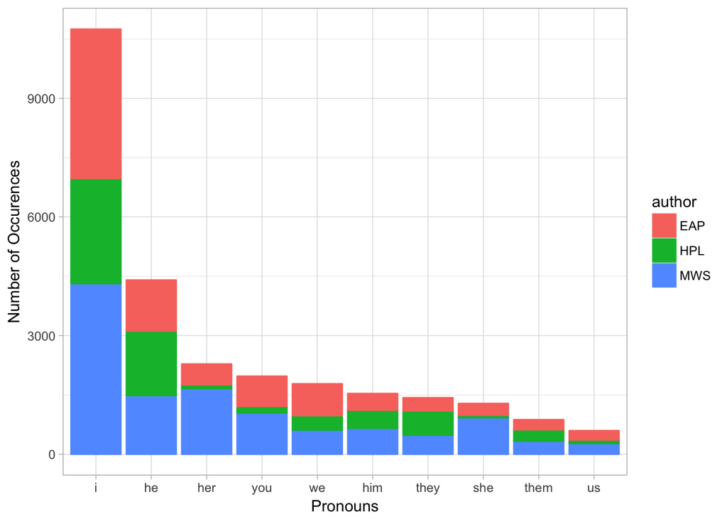

```r
pronouns <- c("i", "we", "us", "they", "them", "he", "she", "you", "him", "her")
spooky_pronouns <- filter(spooky_wrd, word %in% pronouns)


pronoun_plot <- spooky_wrd %>%
  filter(word %in% pronouns)

#png("../figs/pronounplot.png")
  ggplot(pronoun_plot, aes(x = reorder(word, -n), y = n)) +
  geom_bar(aes(color = author, fill = author), stat = "identity") +
  xlab("Pronouns") +
  ylab("Number of Occurences") +
  theme_light()
```

```r
#dev.off() # if reproducing, make sure to end the connection with this command when saving images.
```

From the plot, we can see that MWS and EAP tend to talk about themselves more often than HPL. MWS writes about other women (her, she) more frequently than the male authors, perhaps not surprisingly. HPL seems to rarely refer to women in his work, though he is also seemingly less likely than the other authors to use pronouns in his writing at all.

Next, I compare the average sentence lengths and word lengths of each author.

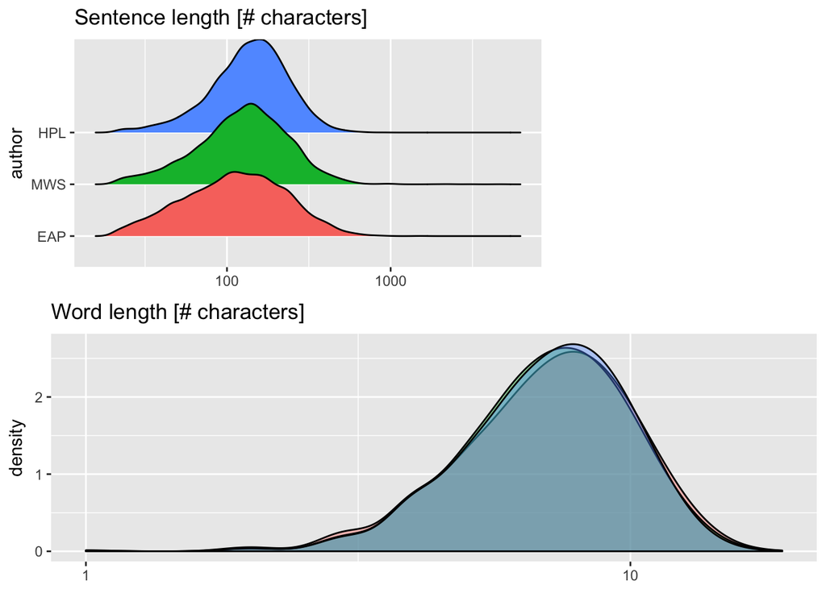

```r
# add length column
spooky <- spooky %>%
  mutate(sen_length = str_length(text))

spooky <- spooky %>%
  group_by(author) %>%
  mutate(Avg = round(mean(sen_length), 2)) %>%
  ungroup() %>%
  mutate(author = reorder(author, Avg))

# Sentence length
slength <- ggplot(spooky) +
      geom_density_ridges(aes(sen_length, author, fill = author)) +
      scale_x_log10() +
      theme(legend.position = "none") +
      labs(x = NULL) +
      ggtitle("Sentence length [# characters]")

# Word length
spooky_wrd <- spooky_wrd %>%
  mutate(word_length = str_length(word))

wlength <- ggplot(spooky_wrd) +
      geom_density(aes(word_length, fill = author), bw = 0.05, alpha = 0.4) +
      scale_x_log10() +
      theme(legend.position = "none") +
      ggtitle("Word length [# characters]") +
      labs(x = NULL)

# Visualizations
#png("../figs/swlengths.png")
layout <- matrix(c(1, 1, 1, 1, NA, NA, 2, 2, 2, 2, 2, 2), 2, 6, byrow = TRUE)
multiplot(slength, wlength, layout = layout)
```

From the visualizations, we can see that EAP’s sentence length is more variable than the other two authors; he has more sentences that are short *and* long, and thus, actually has more sentences in the dataset overall than the two other authors. MWS and HPL’s work follow similar trends in terms of sentence length, though it seems that MWS uses longer sentences slightly more frequently. The density chart shows us that the authors use similar word lengths throughout their work.

I then added a column to the table spooky_wrd for the total amount of words each author uses in his/her work to assess the frequency of each word used. Next, I got rid of all the “stopwords” (including the pronouns) in the data to make analysis more interesting.

```r
total_wrds <- spooky_wrd %>%
  group_by(author) %>%
  summarize(total = sum(n))

spooky_wrd <- left_join(spooky_wrd, total_wrds, by = "author")

# rid of stop words
spooky_wrd_clean <- spooky_wrd %>%
  anti_join(stop_words, by = "word")

# added rank and frequency values
spooky_wrd_clean <- spooky_wrd_clean %>%
  group_by(author) %>%
  mutate(rank = row_number(), freq = n/total)

head(spooky_wrd_clean)
```

```
## # A tibble: 6 x 7
## # Groups:   author [3]
##   author    word     n word_length  total  rank        freq
##   <fctr>   <chr> <int>       <int>  <int> <int>       <dbl>
## 1    MWS    life   329           4 165700     1 0.001985516
## 2    MWS    love   273           4 165700     2 0.001647556
## 3    MWS   heart   262           5 165700     3 0.001581171
## 4    EAP    time   260           4 200855     1 0.001294466
## 5    HPL   night   254           5 156263     1 0.001625465
## 6    MWS raymond   248           7 165700     4 0.001496681
```

### Top 10 Words

Next, I visualized each author’s top ten words used in his/her work.

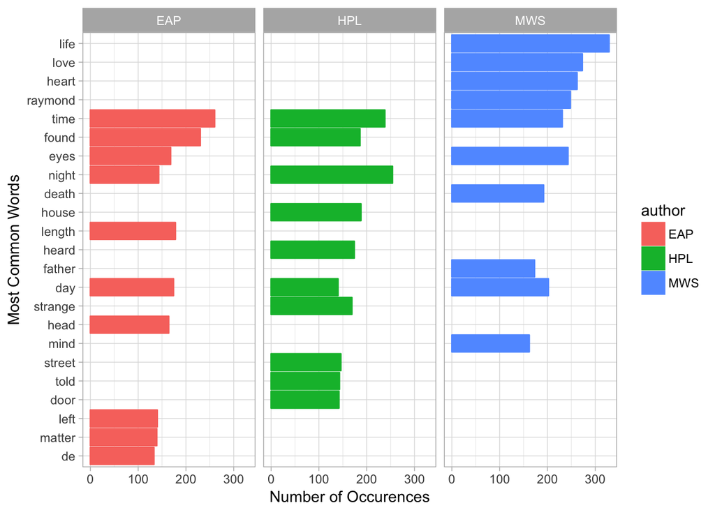

```r
# Top 10 Words Dataframes
top10 <- spooky_wrd_clean %>%
         filter(rank <= 10)

#png("../figs/top10.png")
top10 %>%
  ggplot(., aes(x = reorder(word, n), y = n)) +
  geom_bar(aes(color = author, fill = author), stat = 'identity') +
  facet_wrap(~author) +
  coord_flip() +
  theme_light() +
  ylab("Number of Occurences") +
  xlab("Most Common Words")
```

Some of the authors’ top ten most common words overlap; all three authors like to write about “time” and “day.” We can also see, however, that the two male authors EAP and HPL have slightly more overlapping top words than with MWS. Both male authors frequently use the words “night” and “found.” Other than the words all three authors have in common, EAP overlaps with MWS on the word “eyes” and HPL doesn’t overlap with MWS at all. Given that MWS’s top three words used are “life,” “love,” and “heart,” we may assume that the content of MWS’s work might be more emotional in nature compared to her male counterparts. Her frequent use of the name “Raymond” may be from her work “The Last Man.”

To visualize each author’s top words further, I created three wordclouds. First, Mary Shelley’s.

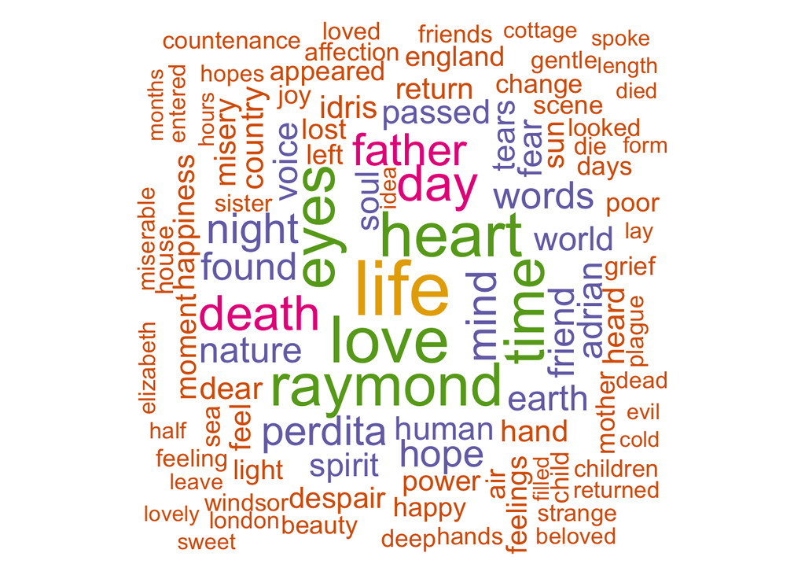

```r
# Word lists by author
MWSwords <- spooky_wrd_clean %>%
  filter(author == "MWS") %>%
  mutate(freq = n/total, rank = row_number()) %>%
  arrange(desc(n))

HPLwords <- spooky_wrd_clean %>%
  filter(author == "HPL") %>%
  mutate(freq = n/total, rank = row_number()) %>%
  arrange(desc(n))

EAPwords <- spooky_wrd_clean %>%
  filter(author == "EAP") %>%
  mutate(freq = n/total, rank = row_number()) %>%
  arrange(desc(n))

# Word Clouds
# MWS wordcloud
#png("../figs/Workcloud_all.png")
wordcloud(words = MWSwords$word, freq = MWSwords$freq, max.words = 100,
                  random.order = FALSE, rot.per = 0.35, colors = brewer.pal(6, "Dark2"))
```

Next, HP Lovecraft’s word cloud:

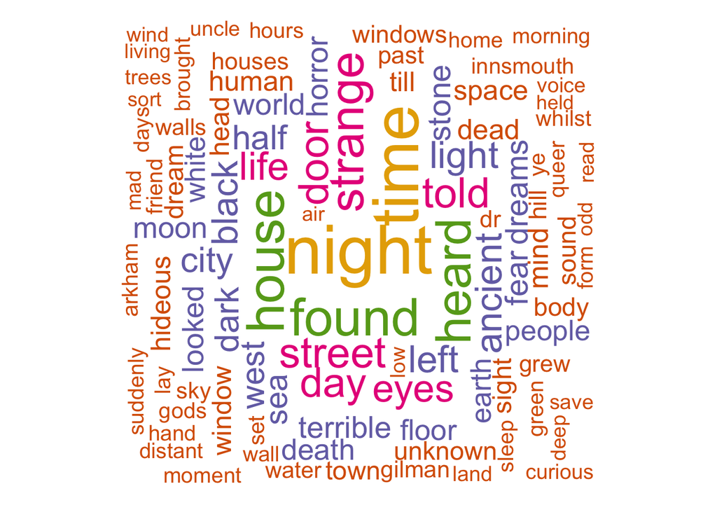

```r
# HPL wordcloud
#png("../figs/hplWC.png")
wordcloud(words = HPLwords$word, freq = HPLwords$freq, max.words = 100,
                  random.order = FALSE, rot.per = 0.35, colors = brewer.pal(6, "Dark2"))
```

Lastly, Poe’s.

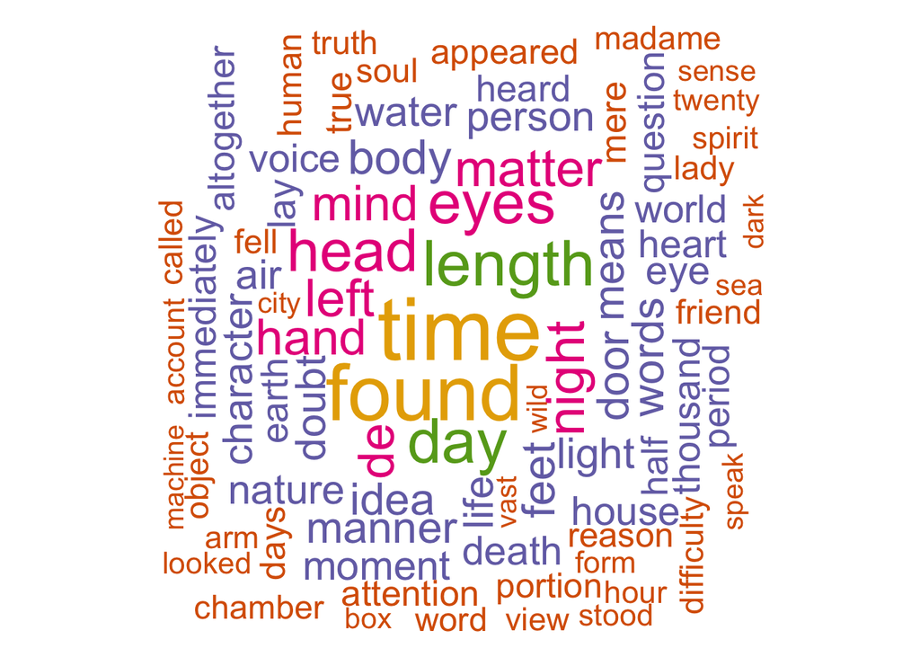

```r
# EAP wordcloud
#png("../figs/eapWC.png")
wordcloud(words = EAPwords$word, freq = EAPwords$freq, max.words = 100,
                  random.order = FALSE, rot.per = 0.35, colors = brewer.pal(6, "Dark2"))
```

Through the word clouds, we can see that MWS’s work is almost certainly more emotional than her counterparts’. Her work tends to paint a seemingly beautiful picture of nature, earth, family combined with suffering and grief. HPL’s wordcloud exemplifies his use of creepier stories in his work. By linking together a few words like “street,” “door,” “horror,” “dark,” “terrible,” “dream,” “hideous,” we can almost recreate a story ourselves. EAP’s wordcloud doesn’t immediately introduce an obvious (to me) theme other than potentially something spiritual, so I’ll dig further through sentiment analysis.

### TF - IDF

After looking into each author’s top 10 words, I want to identify each author’s most used word that is also unique to his/her work. The “tf-idf” is known as the product of term and inverse frequency. The “tf” is the number of times a word appeared in a document or set of documents. The “idf” measures this frequency in relation to others. The weight for more commonly used words is decreased and the weight for words that aren’t used very much in a collection of texts is increased. Thus, the “tf-idf” is “intended to measure how important a word is to a document in a collection of documents” ([TidyTextMining](https://www.tidytextmining.com/tfidf.html)). Words that MWS uses frequently that aren’t used as much by the other authors are in blue; EAP’s most common and unique words are in red and HPL’s are in green.

First, I plotted the relationship between the author’s most frequently used words and their rank. We can see that the relationship between each word’s rank and frequency has a negative slope and that all three authors’ work follows this pattern. Then, I plot the tf-idfs to see which words are most important to each author.

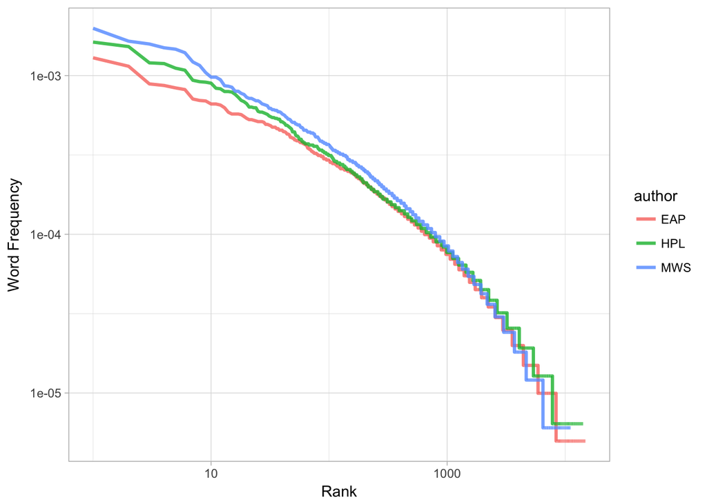

```r
spooky_wrd_clean %>%
  ggplot(aes(rank, freq, color = author)) +
  geom_line(size = 1.1, alpha = 0.8) +
  scale_x_log10() +
  scale_y_log10() +
  xlab("Rank") +
  ylab("Word Frequency") +
  theme_light()
```

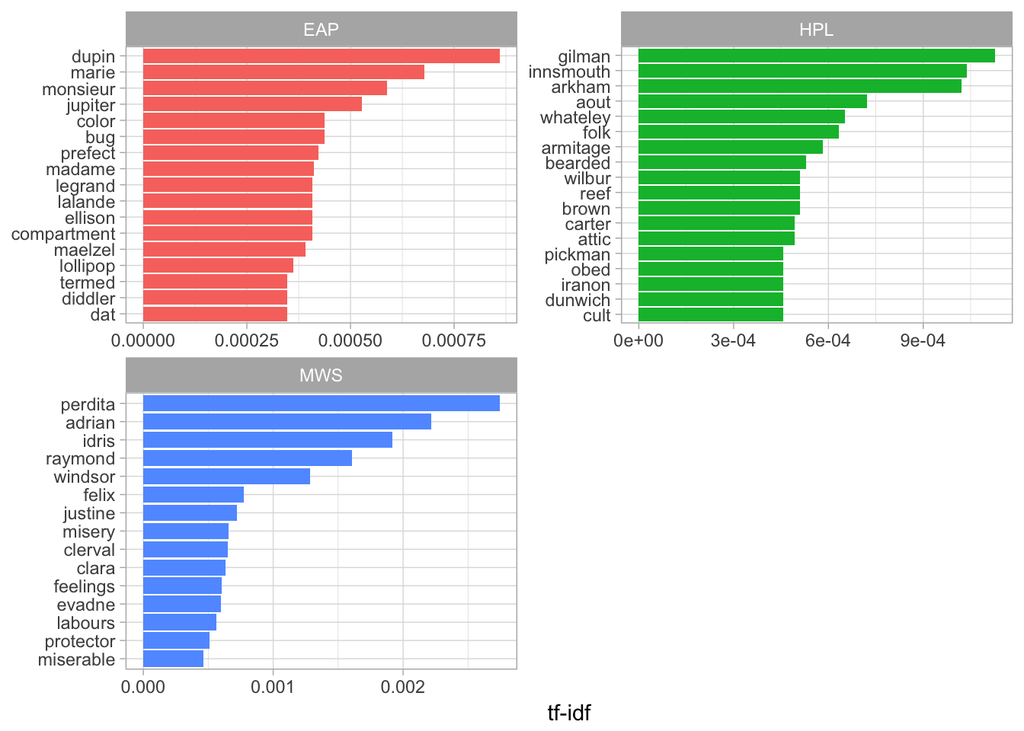

```r
idftf <- spooky_wrd_clean %>%
  bind_tf_idf(word, author, n)

idftf <- idftf %>%
  select(-total) %>%
  arrange(desc(tf_idf))

#png("../figs/tfidf.png")
idftf %>%
  arrange(desc(tf_idf)) %>%
  mutate(word = factor(word, levels = rev(unique(word)))) %>%
  group_by(author) %>%
  top_n(15) %>%
  ungroup %>%
  ggplot(aes(reorder(word,tf_idf), tf_idf, fill = author)) +
  geom_col(show.legend = FALSE) +
  labs(x = NULL, y = "tf-idf") +
  facet_wrap(~author, ncol = 2, scales = "free") +
  coord_flip() +
  theme_light()
```

Many of the unique and important words that the authors use are names (MWS used “perdita”, “adrian”, “raymond” and “idris” while HPL uses “gilman”and “wilbur”). EAP seems to be the only author that uses French frequently in his writing. These charts give us a good idea of what words we would look for if we needed to predict which author wrote a specific piece. Next, I turn to sentiment analysis to understand the emotions and feelings behind each author’s work.

### Sentiment Analysis

#### Positive v. Negative

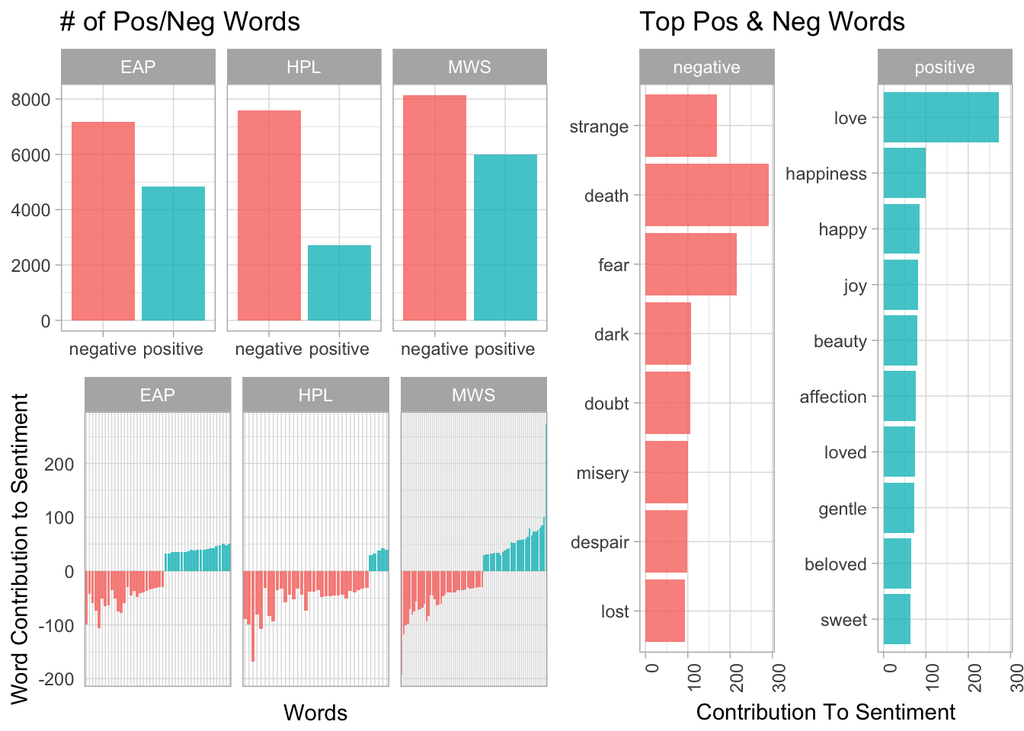

```r
pn_sentiments <- spooky_wrd_clean %>%
  inner_join(get_sentiments("bing"), by = c(word = "word"))

# Negative and positive sentiments by word/ author
author_sent <- pn_sentiments %>%
  count(sentiment, word, wt = n) %>%
  ungroup() %>%
  filter(nn >= 30) %>% # only look at words that appear more than 30 times
  mutate(nn = ifelse(sentiment == "negative", -nn, nn)) %>%
  mutate(word = reorder(word, nn)) %>%
  ggplot(aes(word, nn, fill = sentiment)) +
  geom_bar(alpha = 0.8, stat = "identity", show.legend = FALSE) +
  theme_light() +
  theme(axis.text.x = element_blank(), axis.ticks = element_blank()) +
  ylab("Word Contribution to Sentiment") +
  xlab("Words") +
  facet_wrap(~author, scales = "free_x")

# Top 10 positive and negative words used
total_sent <- pn_sentiments %>%
  subset(select = c(word, sentiment, n)) %>%
  group_by(sentiment) %>%
  top_n(10) %>%
  ggplot(aes(reorder(word, n), n, fill = sentiment)) +
    geom_bar(alpha = 0.8, stat = "identity", show.legend = FALSE) +
    facet_wrap(~sentiment, scales = "free_y") +
    labs(y = "Contribution To Sentiment", x = NULL) +
    ggtitle("Top Pos & Neg Words") +
    theme_light() +
    theme(axis.text.x = element_text(angle = 90, hjust = 1)) +
    coord_flip()

# Total negative and positive words used by authors
author_sent2 <- pn_sentiments %>%
  count(author, sentiment, wt = n) %>%
  ggplot(aes(sentiment, nn, fill = sentiment)) +
  geom_bar(alpha = 0.8, stat = "identity", show.legend = FALSE) +
  facet_wrap(~author) +
  labs(y = NULL, x = NULL) +
  ggtitle("# of Pos/Neg Words") +
  theme_light()

#png("../figs/posnegwords.png")
layout <- matrix(c(1, 1, 1, 1, 1, 1, 3, 3, 3, 3, 3, 2, 2, 2, 2, 2, 2, 3, 3, 3, 3, 3), 2, 11, byrow = TRUE)
multiplot(author_sent2, author_sent, total_sent, layout = layout)
```

From my analysis, it looks as though MWS uses words that are more frequently categorized as positive as well as more words that are categorized as negative in comparison to both EAP and HPL. It’s possible that MWS simply writes more words that are in the “bing” lexicon, but her positive words almost double HPL’s number of positive words, so I want to dig a little further. I visualize the sentiment score of each author’s top 1000 used words below with a heat map. A more positive word will appear as a light yellow/green and a negative word will appear more blue.

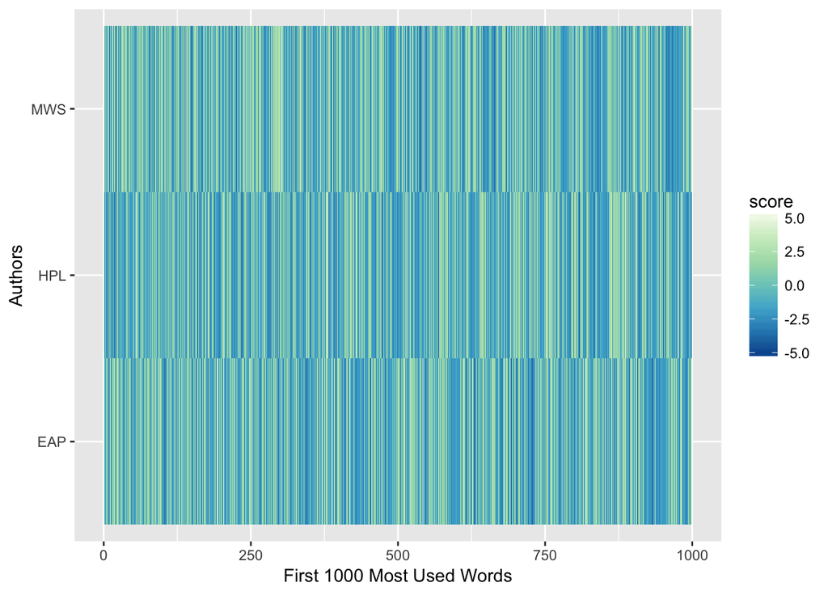

```r
pn_sentiments2 <- spooky_wrd_clean %>%
  inner_join(get_sentiments("afinn"), by = c(word = "word")) %>%
  group_by(author) %>%
  mutate(rank = row_number()) %>%
  filter(rank < 1000) %>%
  ungroup() %>%
  mutate(x = n * score)

hm.palette <- colorRampPalette(rev(brewer.pal(7, 'GnBu')), space='Lab')
#png("../figs/posneghm.png")
ggplot(data = pn_sentiments2, aes(x = rank, y = author)) +
  geom_tile(aes(fill = score), na.rm = TRUE) +
  scale_fill_gradientn(colours = hm.palette(100)) +
  labs(x = "First 1000 Most Used Words", y = "Authors")
```

The heatmap depicts each author’s most commonly used words and their corresponding negative or positive sentiments. We can see chunks of both positive and negative words in all authors’ writing, though MWS seems to have the lightest chunk of the group and HPL and EAP have darker chunks.

Ironically, while MWS seems to be the most “positive” author, she still uses a quarter more negative words than positive words in her pieces; this leads me to think that it’s possible she may be negating the positive words in a way that makes the overall sentiment actually *negative.* Thus, I zoom in to MWS’ work and turn to the “sentimentr” package to analyze multiple words at a time.

### Zooming in: MWS

#### Love

The text in our spooky data is already split up into sentences, so I return to our original spooky data for the following analyses. To examine whether MWS’ high scores on positivity in her work was actually due to negated positive words, I used bigrams and the “AFINN” lexicon to view all words preceded by a negation; From the visualization, we can see which positive-seeming words contribute most to mis-classification.

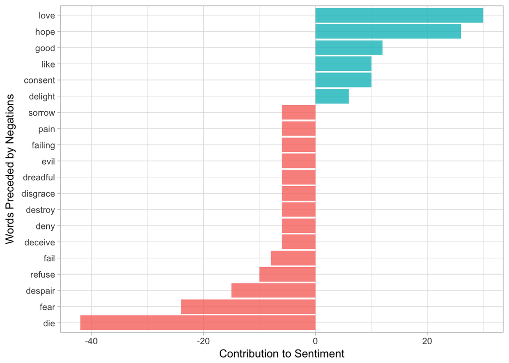

```r
spooky_MWS <- spooky %>%
  filter(author == "MWS")

bigrams <- spooky_MWS %>%
  unnest_tokens(bigram, text, token = "ngrams", n = 2)
bi_sep <- bigrams %>%
  separate(bigram, c("word1", "word2"), sep = " ")
no_words <- c("not", "no", "never", "without")
AFINN <- get_sentiments("afinn")
no_bigram <- bi_sep %>%
  filter(word1 %in% no_words) %>%
  inner_join(AFINN, by = c(word2 = "word")) %>%
  count(word2, score, sort = TRUE) %>%
  ungroup()

#png("../figs/negwrds.png")
no_bigram %>%
  mutate(contribution = n * score) %>%
  arrange(desc(abs(contribution))) %>%
  head(20) %>%
  mutate(word2 = reorder(word2, contribution)) %>%
  ggplot(aes(word2, n * score, fill = n * score > 0)) +
  geom_col(show.legend = FALSE, alpha = 0.8) +
  xlab("Words Preceded by Negations") +
  ylab("Contribution to Sentiment") +
  coord_flip() +
  theme_light()
```

The word “love” has a positive connotation, but in MWS’s work, “love” clearly contributes to a large percent of negated words and thus an incorrect sentiment. I’d argue that the negatively associated words preceded by a negation word likely still contribute to an overall negative sentiment – it’s hard to come up with a truly positive sentence even when negating terms like “sorrow,” “disgrace,” and “dreadful.”

Because “love” is a word quite commonly used by MWS, I look a bit further into words that come before or after “love” to get a better sense of how she means for the word to come across.

```r
# Quadgram for "love"
quadgrams <- spooky_MWS %>%
  unnest_tokens(quadgram, text, token = "ngrams", n = 4)

quad_sep <- quadgrams %>%
  separate(quadgram, c("word1", "word2", "word3", "word4"), sep = " ")

quad_love <- quad_sep %>%
  filter(word1 == "love"| word2 == "love"| word3 == "love"| word4 == "love")

# bigram for love, later.
sub <- select(quad_love, id, author, word3, word4)
bigram_love <- sub %>%
  filter(word4 == "love")

head(quad_love)
```

```
## # A tibble: 6 x 8
##        id author sen_length    Avg   word1   word2     word3     word4
##     <chr> <fctr>      <int>  <dbl>   <chr>   <chr>     <chr>     <chr>
## 1 id00073    MWS        161 151.66 disdain    than      your      love
## 2 id00109    MWS        320 151.66     the  spirit        of      love
## 3 id00109    MWS        320 151.66  spirit      of      love        of
## 4 id00109    MWS        320 151.66      of    love        of rapturous
## 5 id00109    MWS        320 151.66    love      of rapturous  sympathy
## 6 id00138    MWS         64 151.66    back without       his      love
```

After purusing the words that come before and after “love” in MWS’s work, I sense sadness over positivity. I next try using the “afinn” lexicon to score four-word chunks for positive and negative sentiments rather than individual words. Ideally, I’d like to use the “nrc” lexicon to assess sadness rather than simply positivity or negativity, but because each sentence is built up of multiple words, I must use a numeric lexicon.

```r
# combine words into sentences, rid of unused columns
quad_love$text <- paste(quad_love$word1,"", quad_love$word2, "", quad_love$word3, "", quad_love$word4)
sub <- select(quad_love, id, text)

# get sentiments for sentences with "love" in them
love_sent <- sub %>%
        group_by(id) %>%
        unnest_tokens(word, text) %>%
        inner_join(get_sentiments("afinn")) %>%
        group_by(id) %>%
        summarise(sentiment = sum(score, na.rm = TRUE)) %>%
        arrange(desc(sentiment)) %>%
        mutate(sentence_num = row_number())

head(love_sent)
```

```
## # A tibble: 6 x 3
##        id sentiment sentence_num
##     <chr>     <int>        <int>
## 1 id17485        54            1
## 2 id27184        42            2
## 3 id05875        39            3
## 4 id06511        36            4
## 5 id06165        28            5
## 6 id26320        28            6
```

```r
tail(love_sent)
```

```
## # A tibble: 6 x 3
##        id sentiment sentence_num
##     <chr>     <int>        <int>
## 1 id21068         2          248
## 2 id00073         1          249
## 3 id02500         1          250
## 4 id06302         1          251
## 5 id13814         1          252
## 6 id26098         0          253
```

Given the sentiment scores for sentences with the word “love” in them range between 0-54 (which are all positive numbers), I think I’m wrong! MWS may be writing about love in a positive way rather than a sad way. Next, I visualize the most frequent words that come before “love” and their corresponding contribution to either a negative or positive sentiment.

```r
# Get rid of my own stop words.
my_stop_words <- c("of", "and", "to", "the", "a", "as", "that", "by")
x <- removeWords(bigram_love$word3, my_stop_words)
bigram_love$new <- x
bigram_love$word3 <- bigram_love$new
bigram_love$new <- NA

loveplot1 <- bigram_love %>%
  count(word3, word4) %>%
  arrange(desc(n)) %>%
  filter(n > 1& n < 20) %>%
  spread(word4, n, fill = 0) %>%
  ggplot(., aes(x = reorder(word3, love), love, fill = love)) +
  geom_col(alpha = 0.8) +
  ggtitle("Words That Come Before Love") +
  xlab(NULL) +
  ylab(NULL) +
  labs(fill='Frequency') +
  coord_flip() +
  theme_light()

loveplot2 <- bigram_love %>%
  count(word3, word4) %>%
  arrange(desc(n)) %>%
  spread(word4, n, fill = 0) %>%
  inner_join(get_sentiments("afinn"), by = c(word3 = "word")) %>%
  arrange(desc(score)) %>%
  ggplot(., aes(x = reorder(word3, score * love), love * score, fill = love * score > 0)) +
  geom_col(alpha = 0.8) +
  xlab(NULL) +
  ylab(NULL) +
  scale_fill_discrete(name="Contribution to Sentiment", labels=c("Negative", "Positive")) +
  coord_flip() +
  theme_light()
```

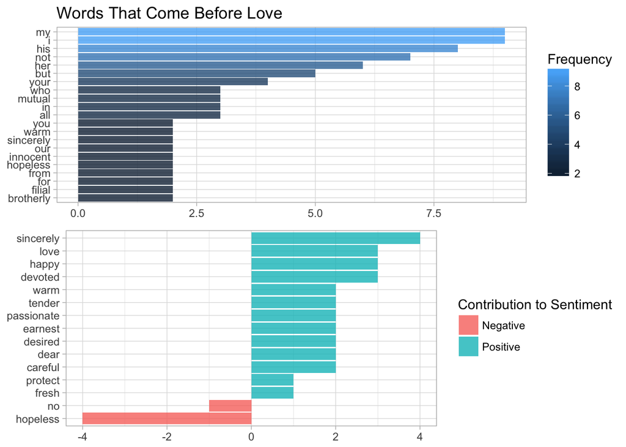

```r
#png("../figs/loveplts.png")
layout <- matrix(c(1, 1, 1, 1, 2, 2, 2, 2), 2, 4, byrow = TRUE)
multiplot(loveplot1, loveplot2, layout = layout)
```

The top plot shows the most common words MWS uses before “love” in her work. Often, she’s talking about her own love, and the words that follow seem primarily positive. The second visualization again cements the notion that MWS is usually speaking about something positive when she writes about love. However, it’s clear that the “afinn” lexicon couldn’t fully represent sentiments of all of the preceding words; for instance, the words “mutual” and “love” combined normally would denote positivity, but “afinn” doesn’t have a sentiment for “mutual.” I also noticed that MWS sometimes speaks about “unrequited” love, another word that the “afinn” lexicon doesn’t define as positive or negative.

#### K-Means Clustering

Lastly, I transform the tidy data into a document term matrix in order to run k-means analysis on MWS’ work to see if there are any natural groups of her work. After trial and error, I set the number of clusters to four and ultimately try to understand the meaning behind each cluster.

```r
# Create Document Term Matrix
dtm <- spooky %>%
  unnest_tokens(word, text) %>%
  count(id, word) %>%
  cast_dtm(id, word, n)

head(findFreqTerms(dtm, lowfreq = 100)) # view terms that appear at least 100 times
```

```
## [1] "idris" "of"    "this"  "was"   "well"  "with"
```

```r
dtm.mat <- as.matrix(dtm) # transform to matrix
dtm.mat <- dtm.mat[,!colnames(dtm.mat)%in%stopwords()] # rid of stop words

df <- spooky[,c("id","author")]
MWS <- which(df$author == "MWS") # identify which are MWS
dtm_MWS <- dtm.mat[MWS, ] # matrix with only MWS work

# K Means
set.seed(2018)
km <- kmeans(dtm_MWS, centers = 4)
glance(km)
```

```
##      totss tot.withinss betweenss iter
## 1 83858.34     82686.56  1171.772    3
```

```r
# Documents in each cluster use words like:
names(head(sort(km$centers[4,], decreasing = TRUE), 16))
```

```
##  [1] "life"  "place" "us"    "every" "now"   "death" "like"  "let"
##  [9] "might" "felt"  "heart" "man"   "yet"   "love"  "thy"   "will"
```

```r
names(head(sort(km$centers[3,], decreasing = TRUE), 16))
```

```
##  [1] "upon"   "one"    "now"    "thus"   "will"   "looked" "first"
##  [8] "even"   "us"     "day"    "eyes"   "length" "great"  "time"
## [15] "long"   "every"
```

```r
names(head(sort(km$centers[2,], decreasing = TRUE), 16))
```

```
##  [1] "one"    "now"    "might"  "will"   "seemed" "little" "two"
##  [8] "man"    "time"   "old"    "thing"  "even"   "like"   "found"
## [15] "yet"    "see"
```

```r
names(head(sort(km$centers[1,], decreasing = TRUE), 16))
```

```
##  [1] "now"   "will"  "man"   "time"  "said"  "yet"   "even"  "old"
##  [9] "must"  "first" "never" "like"  "night" "many"  "eyes"  "great"
```

The last cluster uses words like “life,” “death” and “love,” and the third uses “looked,” “eyes,” “long.” The clusters may be representing different emotions or types of story-telling MWS engaged in. I can certainly see why some of these words might be classified into separate clusters, but this analysis ultimately doesn’t do much to add to our understanding of MWS’s work.